# Final Exam

2024-07-13

```r
library(survival)

data(pbc)

?pbc
```

```
## starting httpd help server ... done
```

```r
summary(pbc)
```

```
##        id             time          status            trt
##  Min.   :  1.0   Min.   :  41   Min.   :0.0000   Min.   :1.000
##  1st Qu.:105.2   1st Qu.:1093   1st Qu.:0.0000   1st Qu.:1.000
##  Median :209.5   Median :1730   Median :0.0000   Median :1.000
##  Mean   :209.5   Mean   :1918   Mean   :0.8301   Mean   :1.494
##  3rd Qu.:313.8   3rd Qu.:2614   3rd Qu.:2.0000   3rd Qu.:2.000
##  Max.   :418.0   Max.   :4795   Max.   :2.0000   Max.   :2.000
##                                                  NA's   :106
##       age        sex        ascites            hepato          spiders
##  Min.   :26.28   m: 44   Min.   :0.00000   Min.   :0.0000   Min.   :0.0000
##  1st Qu.:42.83   f:374   1st Qu.:0.00000   1st Qu.:0.0000   1st Qu.:0.0000
##  Median :51.00           Median :0.00000   Median :1.0000   Median :0.0000
##  Mean   :50.74           Mean   :0.07692   Mean   :0.5128   Mean   :0.2885
##  3rd Qu.:58.24           3rd Qu.:0.00000   3rd Qu.:1.0000   3rd Qu.:1.0000
##  Max.   :78.44           Max.   :1.00000   Max.   :1.0000   Max.   :1.0000
##                          NA's   :106       NA's   :106      NA's   :106
##      edema             bili             chol           albumin
##  Min.   :0.0000   Min.   : 0.300   Min.   : 120.0   Min.   :1.960
##  1st Qu.:0.0000   1st Qu.: 0.800   1st Qu.: 249.5   1st Qu.:3.243
##  Median :0.0000   Median : 1.400   Median : 309.5   Median :3.530
##  Mean   :0.1005   Mean   : 3.221   Mean   : 369.5   Mean   :3.497
##  3rd Qu.:0.0000   3rd Qu.: 3.400   3rd Qu.: 400.0   3rd Qu.:3.770
##  Max.   :1.0000   Max.   :28.000   Max.   :1775.0   Max.   :4.640
##                                    NA's   :134
##      copper          alk.phos            ast              trig
##  Min.   :  4.00   Min.   :  289.0   Min.   : 26.35   Min.   : 33.00
##  1st Qu.: 41.25   1st Qu.:  871.5   1st Qu.: 80.60   1st Qu.: 84.25
##  Median : 73.00   Median : 1259.0   Median :114.70   Median :108.00
##  Mean   : 97.65   Mean   : 1982.7   Mean   :122.56   Mean   :124.70
##  3rd Qu.:123.00   3rd Qu.: 1980.0   3rd Qu.:151.90   3rd Qu.:151.00
##  Max.   :588.00   Max.   :13862.4   Max.   :457.25   Max.   :598.00
##  NA's   :108      NA's   :106       NA's   :106      NA's   :136
##     platelet        protime          stage
##  Min.   : 62.0   Min.   : 9.00   Min.   :1.000
##  1st Qu.:188.5   1st Qu.:10.00   1st Qu.:2.000
##  Median :251.0   Median :10.60   Median :3.000
##  Mean   :257.0   Mean   :10.73   Mean   :3.024
##  3rd Qu.:318.0   3rd Qu.:11.10   3rd Qu.:4.000
##  Max.   :721.0   Max.   :18.00   Max.   :4.000
##  NA's   :11      NA's   :2       NA's   :6
```

## Q1: Use the code below for converting a couple of variables into factors, from their original type. What is the purpose behind these conversions? Base you answer in the contextual information related to the dataset. This information can be pulled up by using the help function on pbc

```r
my.pbc <- na.omit(pbc[, -1])

my.pbc$status <- as.factor(my.pbc$status) # status should be a factor
my.pbc$ascites <- as.factor(my.pbc$ascites) # ascites should be factor
my.pbc$hepato <- as.factor(my.pbc$hepato) # hepato should be factor
my.pbc$stage <- as.factor(my.pbc$stage) # stage is ordinal/rank

summary(my.pbc)
```

```
##       time      status       trt             age        sex     ascites hepato
##  Min.   :  41   0:147   Min.   :1.000   Min.   :26.28   m: 34   0:257   0:134
##  1st Qu.:1186   1: 18   1st Qu.:1.000   1st Qu.:41.51   f:242   1: 19   1:142
##  Median :1788   2:111   Median :2.000   Median :49.71
##  Mean   :1979           Mean   :1.507   Mean   :49.80
##  3rd Qu.:2690           3rd Qu.:2.000   3rd Qu.:56.58
##  Max.   :4556           Max.   :2.000   Max.   :78.44
##     spiders           edema             bili             chol
##  Min.   :0.0000   Min.   :0.0000   Min.   : 0.300   Min.   : 120.0
##  1st Qu.:0.0000   1st Qu.:0.0000   1st Qu.: 0.800   1st Qu.: 249.5
##  Median :0.0000   Median :0.0000   Median : 1.400   Median : 310.0
##  Mean   :0.2899   Mean   :0.1069   Mean   : 3.334   Mean   : 371.3
##  3rd Qu.:1.0000   3rd Qu.:0.0000   3rd Qu.: 3.525   3rd Qu.: 401.0
##  Max.   :1.0000   Max.   :1.0000   Max.   :28.000   Max.   :1775.0
##     albumin          copper          alk.phos            ast
##  Min.   :1.960   Min.   :  4.00   Min.   :  289.0   Min.   : 28.38
##  1st Qu.:3.310   1st Qu.: 42.75   1st Qu.:  922.5   1st Qu.: 82.46
##  Median :3.545   Median : 74.00   Median : 1277.5   Median :116.62
##  Mean   :3.517   Mean   :100.77   Mean   : 1996.6   Mean   :124.12
##  3rd Qu.:3.772   3rd Qu.:129.25   3rd Qu.: 2068.2   3rd Qu.:153.45
##  Max.   :4.400   Max.   :588.00   Max.   :13862.4   Max.   :457.25
##       trig          platelet        protime      stage
##  Min.   : 33.0   Min.   : 62.0   Min.   : 9.00   1: 12
##  1st Qu.: 85.0   1st Qu.:200.0   1st Qu.:10.00   2: 59
##  Median :108.0   Median :257.0   Median :10.60   3:111
##  Mean   :125.0   Mean   :261.8   Mean   :10.74   4: 94
##  3rd Qu.:151.2   3rd Qu.:318.2   3rd Qu.:11.20
##  Max.   :598.0   Max.   :563.0   Max.   :17.10
```

##Interpretation:

The data shows the patient history of the majority of female patients with liver-related diseases. Other factors like bilirubin, AST, alkaline phosphatase, and albumin demonstrate that most of these patients have severely affected liver functions. People’s ages vary from 26 to 78 years; the mean age is about 50 years. These data indicate a shift of the patients towards the later stages of the disease (predominantly stages 2, 3, and 4), which points to the fact that a significant portion of patients suffer from advanced liver disease. Other variables include cholesterol, copper, and platelets, which depict other metabolic and hematologic profiles. This vast database proves useful in understanding the evolution of liver diseases and their effects on patients.

## Q2 a: Execute the code below associated with excluding trt, time, and status from the dataframe to produce a reduced version of the dataset represented by the data frame object labeled my.pbc.

```r
my.reduced.pbc <- my.pbc[, -c(1:3)]
summary(my.reduced.pbc)
```

```
##       age        sex     ascites hepato     spiders           edema
##  Min.   :26.28   m: 34   0:257   0:134   Min.   :0.0000   Min.   :0.0000
##  1st Qu.:41.51   f:242   1: 19   1:142   1st Qu.:0.0000   1st Qu.:0.0000
##  Median :49.71                           Median :0.0000   Median :0.0000
##  Mean   :49.80                           Mean   :0.2899   Mean   :0.1069
##  3rd Qu.:56.58                           3rd Qu.:1.0000   3rd Qu.:0.0000
##  Max.   :78.44                           Max.   :1.0000   Max.   :1.0000
##       bili             chol           albumin          copper
##  Min.   : 0.300   Min.   : 120.0   Min.   :1.960   Min.   :  4.00
##  1st Qu.: 0.800   1st Qu.: 249.5   1st Qu.:3.310   1st Qu.: 42.75
##  Median : 1.400   Median : 310.0   Median :3.545   Median : 74.00
##  Mean   : 3.334   Mean   : 371.3   Mean   :3.517   Mean   :100.77
##  3rd Qu.: 3.525   3rd Qu.: 401.0   3rd Qu.:3.772   3rd Qu.:129.25
##  Max.   :28.000   Max.   :1775.0   Max.   :4.400   Max.   :588.00
##     alk.phos            ast              trig          platelet
##  Min.   :  289.0   Min.   : 28.38   Min.   : 33.0   Min.   : 62.0
##  1st Qu.:  922.5   1st Qu.: 82.46   1st Qu.: 85.0   1st Qu.:200.0
##  Median : 1277.5   Median :116.62   Median :108.0   Median :257.0
##  Mean   : 1996.6   Mean   :124.12   Mean   :125.0   Mean   :261.8
##  3rd Qu.: 2068.2   3rd Qu.:153.45   3rd Qu.:151.2   3rd Qu.:318.2
##  Max.   :13862.4   Max.   :457.25   Max.   :598.0   Max.   :563.0
##     protime      stage
##  Min.   : 9.00   1: 12
##  1st Qu.:10.00   2: 59
##  Median :10.60   3:111
##  Mean   :10.74   4: 94
##  3rd Qu.:11.20
##  Max.   :17.10
```

##Interpretation:

This dataset contains information on 276 patients diagnosed with liver disease, with the majority of the respondents being female (88%). The median age is around 49 years, possibly due to the expansion of elderly health products and services. The clinical signs and symptoms in the patients include ascites in 7% and hepatomegaly in 51%. Spider angiomas are observed in 29% of patients, and edema in 11%. Serum bilirubin level varies from 0. 3 to 28 mg/dL with a mean of 3. 334 mg/dL; cholesterol levels noted mean 371. 3; and albumin level has a mean of 3. 517 g/dL. The average population of platelets is 261. 8 K/μL. Liver enzymes prove the mean of AST to be 124.12 IU/L and a mean adequate prothrombin time of 10.74 seconds. Disease staging shows 40 percent of the patients in Stage 3 and 34 percent in Stage 4. The variations in the liver disease symptoms shown in this study prove that the disease is both diverse and severe in the patients under consideration.

## Q2 b: What would be a suitable model to predict presence of hepatomegaly or enlarged liver using age, sex, albumin, alk.phos , ast, and biliin using the reduced version of the dataset (represented by the dataframe object with the label my.reduced.pbc)? Explain the rationale behind the specific modeling approach you have choose, based on the measurement type of the outcome variable.

The type of model that can be used to estimate the probability of patients with hepatomegaly based on the predictors age, sex, albumin, alk phosphatase, aspartate aminotransaminase, and bilirubin is logistic regression. Logistic regression is more suitable in this regard since hepatomegaly, the outcome variable, is binary, having only two categories: enlarged liver and normal liver. This type of model outputs the probability that a given input point is part of a certain class and, in this case, whether a patient has hepatomegaly or not. In addition to the probability of the presence of hepatomegaly given the predictors, logistic regression will offer odds ratios for each predictor. Hence, these odds ratios are important when describing the degree and direction of the relationship between each predictor and hepatomegaly risk. On the basis of logistic regression analysis, one can determine the peculiarities of the demographic and clinical factors that could define the tendency towards the development of hepatomegaly.

## Q2 c: Explain the purpose behind excluding the variables trt, time, and status variables as predictors: what is gained by excluding these variables as predictors? What would be a consequence if these three variables were retained and used as predictors?

Excluding the variables treatment (trt), time, and status from the logistic regression model is important for clarity and accuracy.

1.Treatment (trt):This variable refers to any interventions the patients might have received. Including it could bias the results because treatments can directly affect the likelihood of hepatomegaly, making it harder to see the true effects of the main predictors like age, sex, albumin, alkaline phosphatase, AST, and bilirubin.

2.Time: This typically represents the follow-up period. It might not directly cause hepatomegaly but rather show how long data was collected. Including time could confuse the model’s interpretation since it might interact with other variables in unpredictable ways.

3.Status: This variable usually indicates whether a patient survived or not. Including it could lead to biased results since it’s an outcome that might be influenced by hepatomegaly or other predictors. It could also cause multicollinearity, where it’s highly correlated with hepatomegaly and other predictors, leading to unstable estimates.

Overall, including these variables would complicate the model and make it harder to see the true relationships between the main predictors and hepatomegaly.

##Q3: Based on your answer for Q2 b, using my.reduced.pbc dataframe , build a model to predict hepato using age, sex, albumin, alk.phos , ast, and biliin

```r
# Load necessary library
library(stats)

# Fit logistic regression model
model <- glm(hepato ~ age + sex + albumin + alk.phos + ast + bili, data = my.reduced.pbc, family = binomial)
summary(model)
```

```
##
## Call:
## glm(formula = hepato ~ age + sex + albumin + alk.phos + ast +
##     bili, family = binomial, data = my.reduced.pbc)
##
## Coefficients:
##               Estimate Std. Error z value Pr(>|z|)
## (Intercept)  3.895e+00  1.846e+00   2.109  0.03491 *
## age          1.463e-04  1.331e-02   0.011  0.99123
## sexf        -4.393e-01  4.052e-01  -1.084  0.27835
## albumin     -1.127e+00  3.788e-01  -2.975  0.00293 **
## alk.phos     8.450e-05  6.426e-05   1.315  0.18851
## ast         -8.970e-04  2.672e-03  -0.336  0.73709
## bili         1.600e-01  5.138e-02   3.115  0.00184 **
## ---
## Signif. codes:  0 '***' 0.001 '**' 0.01 '*' 0.05 '.' 0.1 ' ' 1
##
## (Dispersion parameter for binomial family taken to be 1)
##
##     Null deviance: 382.39  on 275  degrees of freedom
## Residual deviance: 340.36  on 269  degrees of freedom
## AIC: 354.36
##
## Number of Fisher Scoring iterations: 5
```

##Interpretation:

## Q3 a: Significant predictors.

Significant Predictors:

Albumin: Higher levels are associated with lower odds of hepato. Bilirubin (bili): Higher levels are associated with higher odds of hepato.

Predictors with p-values less than 0.05 are considered significant.

## Q3 b: Interpret the odds ratio of serum bilirubin (bili) and presence of hepatomegaly.

```r
# Calculate the odds ratio for serum bilirubin (bili)
odds_ratio_bili <- exp(coef(model)["bili"])
odds_ratio_bili
```

```
##     bili
## 1.173551
```

## Q4: For the model constructed in Q3, perform the needed key diagnostics and interpret the results of the model based on what you find here.

```r
library(dplyr)
```

```r
library(ggplot2)
library(faraway)
my.reduced.pbc <- mutate(my.reduced.pbc, residuals=residuals(model), linpred=predict(model))
gdf <- group_by(my.reduced.pbc, cut(linpred, breaks=unique(quantile(linpred, (1:100)/101))))
```

```r
diagdf <- summarise(gdf, residuals=mean(residuals), linpred=mean(linpred))
```

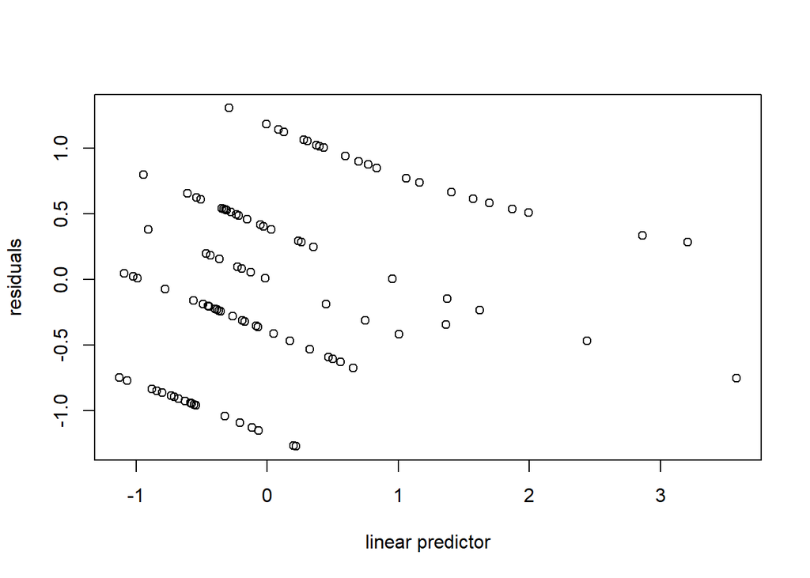

```r
plot(residuals ~ linpred, diagdf, xlab="linear predictor")
```

## Interpretation:

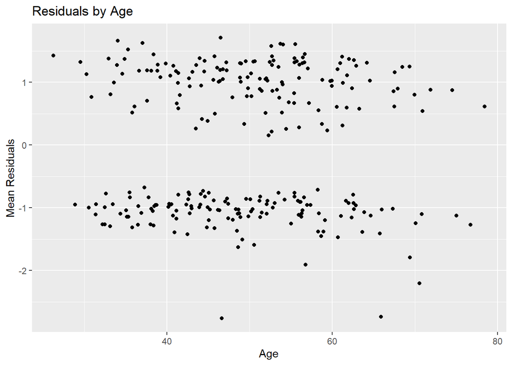

```r
# Group by age and plot
library(dplyr)
library(ggplot2)

my.reduced.pbc %>%
  group_by(age) %>%
  summarise(residuals = mean(residuals)) %>%
  ggplot(aes(x = age, y = residuals)) +
  geom_point() +
  labs(title = "Residuals by Age", x = "Age", y = "Mean Residuals")
```

##Interpretation:

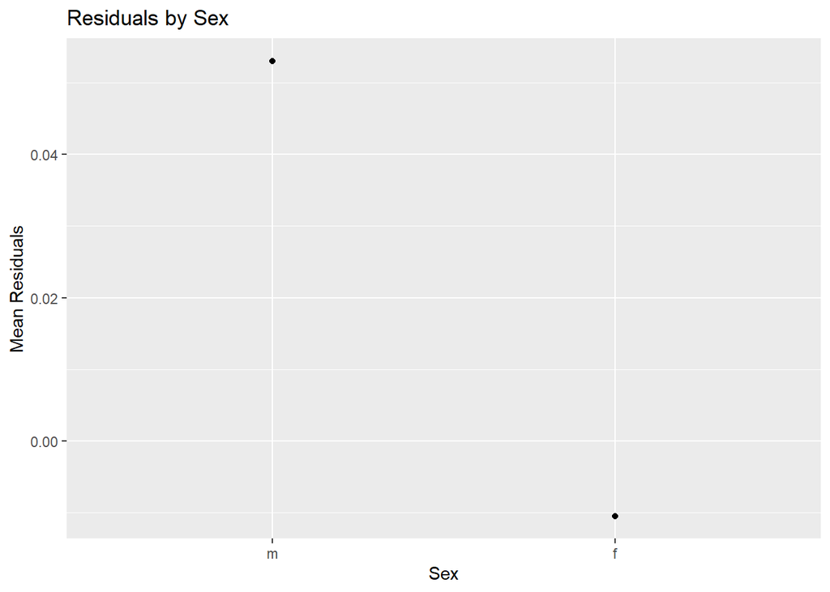

```r
# Group by sex and plot
my.reduced.pbc %>%
  group_by(sex) %>%
  summarise(residuals = mean(residuals)) %>%
  ggplot(aes(x = sex, y = residuals)) +
  geom_point() +
  labs(title = "Residuals by Sex", x = "Sex", y = "Mean Residuals")
```

##Interpretation:

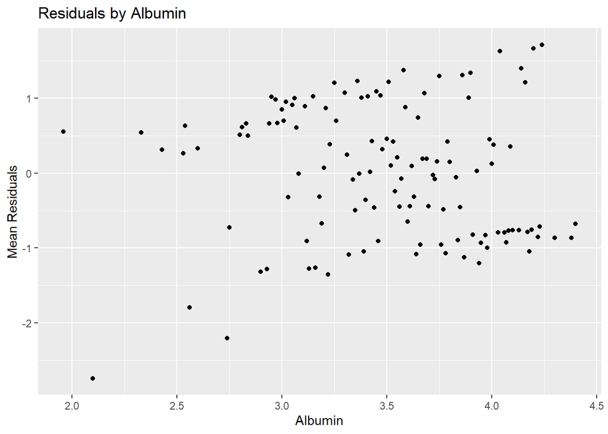

```r
# Group by albumin and plot
my.reduced.pbc %>%
  group_by(albumin) %>%
  summarise(residuals = mean(residuals)) %>%
  ggplot(aes(x = albumin, y = residuals)) +
  geom_point() +
  labs(title = "Residuals by Albumin", x = "Albumin", y = "Mean Residuals")
```

##Interpretation:

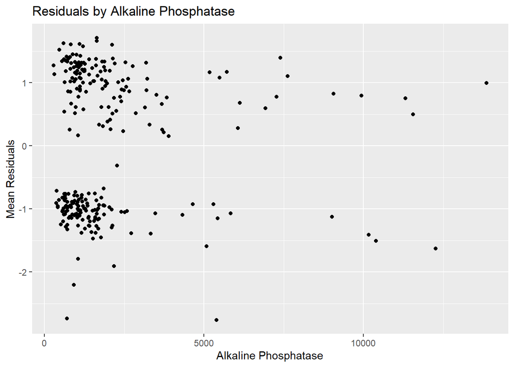

```r
# Group by alkaline phosphatase and plot
my.reduced.pbc %>%
  group_by(alk.phos) %>%
  summarise(residuals = mean(residuals)) %>%
  ggplot(aes(x = alk.phos, y = residuals)) +
  geom_point() +
  labs(title = "Residuals by Alkaline Phosphatase", x = "Alkaline Phosphatase", y = "Mean Residuals")
```

##Interpretation:

The graph shows the residuals of a model plotted against alkaline phosphatase levels, which range from 0 to over 10,000. The residuals cluster densely around lower alkaline phosphatase values (0-2000) with a spread between -2 and +2, indicating high variability. As alkaline phosphatase values increase beyond 2000, the residuals become more sparse but show a wider spread, particularly with some high residuals above +1 and low residuals below -2, suggesting the model’s prediction accuracy diminishes for higher alkaline phosphatase values.

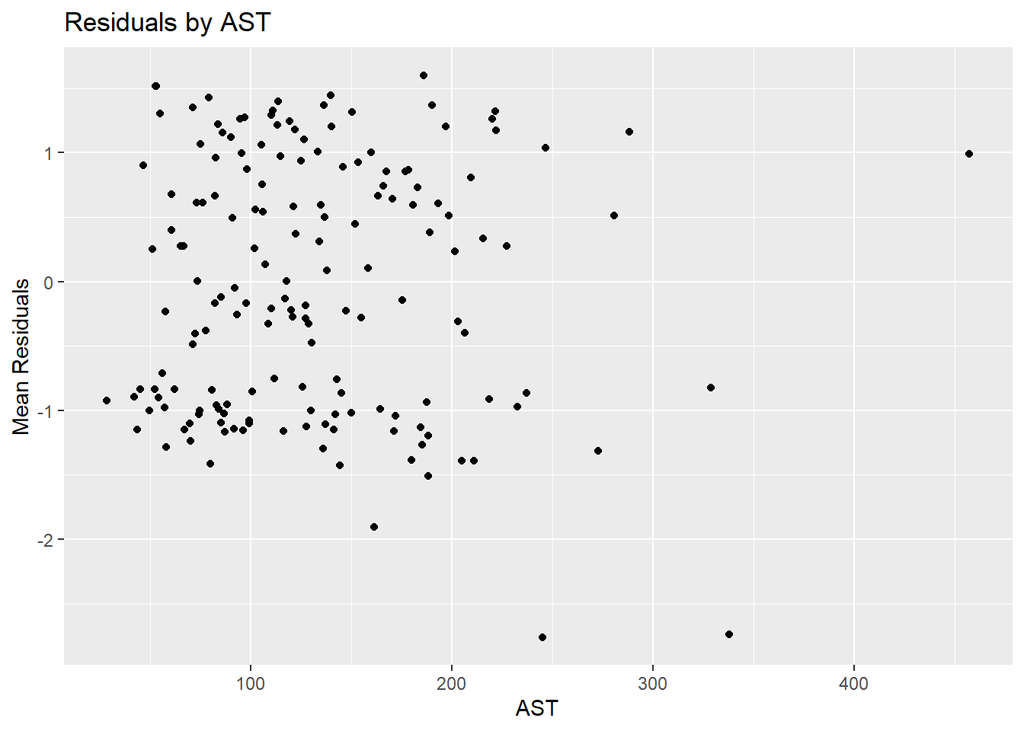

```r
# Group by AST and plot
my.reduced.pbc %>%
  group_by(ast) %>%
  summarise(residuals = mean(residuals)) %>%
  ggplot(aes(x = ast, y = residuals)) +
  geom_point() +
  labs(title = "Residuals by AST", x = "AST", y = "Mean Residuals")
```

##Interpretation:

The scatter plot shows the residuals of a regression model plotted against the aspartate aminotransferase (AST) values. The residuals, which range from approximately -2.5 to 1.5, are plotted on the y-axis, while the AST values, ranging from approximately 10 to 450, are plotted on the x-axis. The residuals appear to be randomly distributed around the zero line, with no clear pattern, trend, or funnel shape, suggesting that the model fits the data well and that the assumptions of linearity and homoscedasticity (constant variance of residuals) are reasonably met. However, there is a slight indication of increased variance at higher AST values, although this does not seem substantial. The majority of the residuals are within the range of -1 to 1, indicating that the model’s predictions are generally close to the observed values.

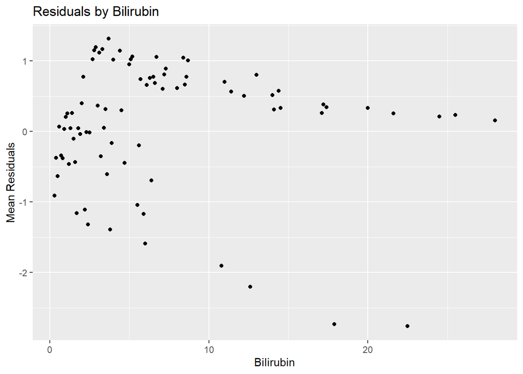

```r
# Group by bilirubin and plot
my.reduced.pbc %>%
  group_by(bili) %>%
  summarise(residuals = mean(residuals)) %>%
  ggplot(aes(x = bili, y = residuals)) +
  geom_point() +
  labs(title = "Residuals by Bilirubin", x = "Bilirubin", y = "Mean Residuals")
```

##Interpretation:

The graph shows the residuals of a model plotted against bilirubin levels, which range from 0 to about 25. The residuals are more concentrated around lower bilirubin values (0-10) and spread between -2 and +1, indicating variability in prediction errors. For bilirubin levels beyond 10, the residuals are more scattered but generally closer to zero, suggesting the model has lower prediction error at higher bilirubin levels. However, there are a few outliers with residuals below -2 and above +1, indicating occasional significant prediction errors.

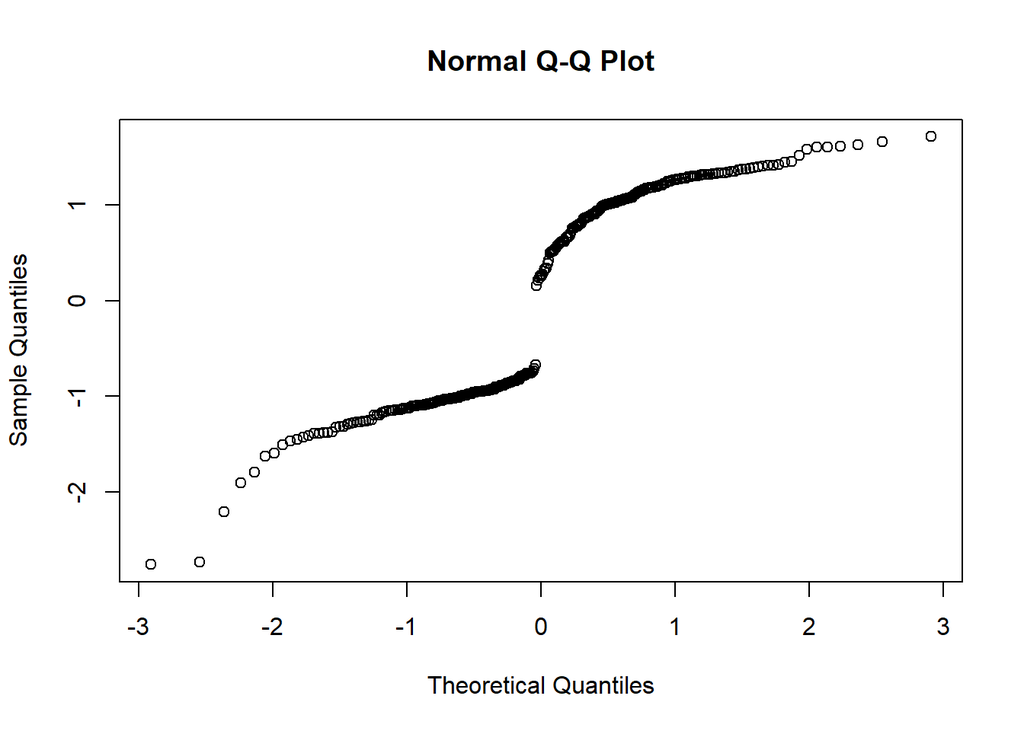

```r
qqnorm(residuals(model))
```

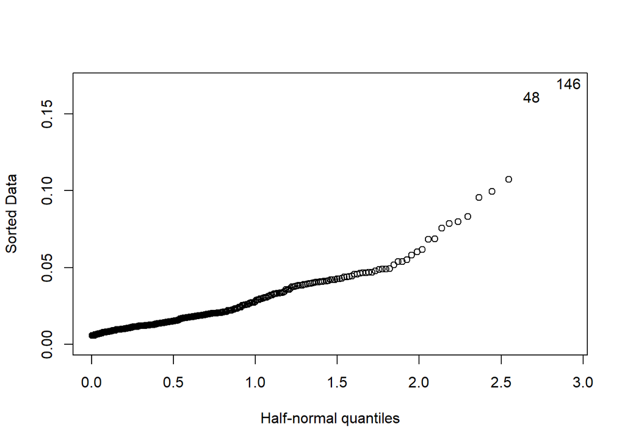

```r
halfnorm(hatvalues(model))
```

##Interpretation:

The Normal Q-Q plot shows the sample quantiles versus the theoretical quantiles from a normal distribution. The points deviate from the diagonal line, particularly at the tails (below -2 and above 2), indicating that the data is not normally distributed. The S-shaped curve suggests a potential bimodal distribution or heavy tails, as the data points show systematic deviations from the expected straight line under normality assumptions.

The half-normal Q-Q plot shows the sorted data versus the half-normal quantiles. The data points follow the reference line closely until around 1.5, indicating a good fit to a half-normal distribution for lower quantiles. Beyond 1.5, the points start deviating upwards, with the maximum sorted data value reaching approximately 0.15, suggesting heavier tails or outliers in the upper quantiles. The numbers 48 and 146 indicate the extreme observations, which deviate the most from the half-normal distribution.

## Q5: Next, use the code below and go back to using my.pbc. Add a new variable to represent two states of status: the original status values of 0 and 1 are mapped to a 0 and the original value of 2 onto a 1. In the R code, this new variable is labeled newstatus. What purpose would be served by combining the original 0 (censored) and 1 (transplant) into a single category, and the original 2 (dead) into another single category? (Hint: consider what you would need for status, if your goal is to model survival/non-survival). What is lost when combining the original 0 and 1 categories into a single new category? How will this affect the interpretation of the results?

```r
my.pbc$newstatus <- as.numeric(ifelse(my.pbc$status == 2, 1, 0))
my.pbc <- my.pbc[, -2] # remove the original status variable

summary(my.pbc)
```

```
##       time           trt             age        sex     ascites hepato
##  Min.   :  41   Min.   :1.000   Min.   :26.28   m: 34   0:257   0:134
##  1st Qu.:1186   1st Qu.:1.000   1st Qu.:41.51   f:242   1: 19   1:142
##  Median :1788   Median :2.000   Median :49.71
##  Mean   :1979   Mean   :1.507   Mean   :49.80
##  3rd Qu.:2690   3rd Qu.:2.000   3rd Qu.:56.58
##  Max.   :4556   Max.   :2.000   Max.   :78.44
##     spiders           edema             bili             chol
##  Min.   :0.0000   Min.   :0.0000   Min.   : 0.300   Min.   : 120.0
##  1st Qu.:0.0000   1st Qu.:0.0000   1st Qu.: 0.800   1st Qu.: 249.5
##  Median :0.0000   Median :0.0000   Median : 1.400   Median : 310.0
##  Mean   :0.2899   Mean   :0.1069   Mean   : 3.334   Mean   : 371.3
##  3rd Qu.:1.0000   3rd Qu.:0.0000   3rd Qu.: 3.525   3rd Qu.: 401.0
##  Max.   :1.0000   Max.   :1.0000   Max.   :28.000   Max.   :1775.0
##     albumin          copper          alk.phos            ast
##  Min.   :1.960   Min.   :  4.00   Min.   :  289.0   Min.   : 28.38
##  1st Qu.:3.310   1st Qu.: 42.75   1st Qu.:  922.5   1st Qu.: 82.46
##  Median :3.545   Median : 74.00   Median : 1277.5   Median :116.62
##  Mean   :3.517   Mean   :100.77   Mean   : 1996.6   Mean   :124.12
##  3rd Qu.:3.772   3rd Qu.:129.25   3rd Qu.: 2068.2   3rd Qu.:153.45
##  Max.   :4.400   Max.   :588.00   Max.   :13862.4   Max.   :457.25
##       trig          platelet        protime      stage     newstatus
##  Min.   : 33.0   Min.   : 62.0   Min.   : 9.00   1: 12   Min.   :0.0000
##  1st Qu.: 85.0   1st Qu.:200.0   1st Qu.:10.00   2: 59   1st Qu.:0.0000
##  Median :108.0   Median :257.0   Median :10.60   3:111   Median :0.0000
##  Mean   :125.0   Mean   :261.8   Mean   :10.74   4: 94   Mean   :0.4022
##  3rd Qu.:151.2   3rd Qu.:318.2   3rd Qu.:11.20           3rd Qu.:1.0000
##  Max.   :598.0   Max.   :563.0   Max.   :17.10           Max.   :1.0000
```

##Interpretation:

## Q6: Fit a CoxPH model to predict the hazard function of newstatus using age+sex+albumin+alk.phos+ast+bili . Identify significant predictors?

```r
cox.model <- coxph(Surv(time, newstatus) ~ age + sex + albumin + alk.phos + ast + bili, data = my.pbc)
summary(cox.model)
```

```
## Call:
## coxph(formula = Surv(time, newstatus) ~ age + sex + albumin +
##     alk.phos + ast + bili, data = my.pbc)
##
##   n= 276, number of events= 111
##
##                coef  exp(coef)   se(coef)      z Pr(>|z|)
## age       3.817e-02  1.039e+00  1.054e-02  3.621 0.000293 ***
## sexf     -5.080e-01  6.017e-01  2.662e-01 -1.909 0.056322 .
## albumin  -1.324e+00  2.661e-01  2.530e-01 -5.233 1.67e-07 ***
## alk.phos  1.926e-05  1.000e+00  3.657e-05  0.527 0.598424
## ast       2.937e-03  1.003e+00  1.605e-03  1.830 0.067309 .
## bili      1.238e-01  1.132e+00  1.598e-02  7.748 9.32e-15 ***
## ---
## Signif. codes:  0 '***' 0.001 '**' 0.01 '*' 0.05 '.' 0.1 ' ' 1
##
##          exp(coef) exp(-coef) lower .95 upper .95
## age         1.0389     0.9625    1.0177    1.0606
## sexf        0.6017     1.6619    0.3571    1.0138
## albumin     0.2661     3.7579    0.1621    0.4369
## alk.phos    1.0000     1.0000    0.9999    1.0001
## ast         1.0029     0.9971    0.9998    1.0061
## bili        1.1318     0.8835    1.0969    1.1679
##
## Concordance= 0.813  (se = 0.022 )
## Likelihood ratio test= 127.9  on 6 df,   p=<2e-16
## Wald test            = 146.5  on 6 df,   p=<2e-16
## Score (logrank) test = 208.5  on 6 df,   p=<2e-16
```

##Interpretation:

## Q7: Identify the key assumption(s) associated with the CoxPH modeling approach, and explain whether it/they are satisfied, using appropriate evidence.

```r
cox.zph(cox.model)
```

```
##            chisq df     p
## age       1.1820  1 0.277
## sex       0.0364  1 0.849
## albumin   0.7477  1 0.387
## alk.phos  0.9330  1 0.334
## ast       0.5804  1 0.446
## bili      8.2985  1 0.004
## GLOBAL   10.8236  6 0.094
```

##Interpretation:

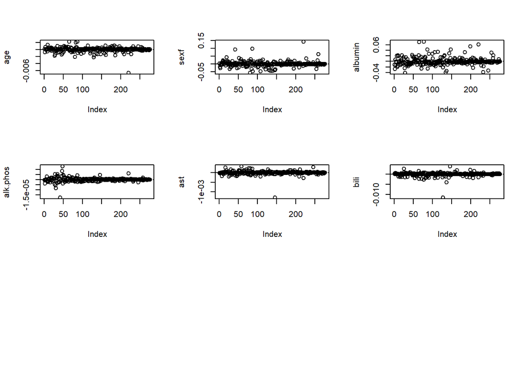

```r
dfbeta <- residuals(cox.model, type="dfbeta")
par(mfrow=c(3,3))
## par(mfrow=c(2,2))
for (j in 1:6) {
  plot(dfbeta[, j], ylab=names(coef(cox.model))[j])
  abline(h=0, lty=2)
}
```

##Interpretation:

*Reflection Questions:*

## Q8: Which aspects of the course material did you find most challenging, and why?

I found the statistical modeling parts of the course to be quite challenging. Understanding complex methods like Cox proportional hazards models and logistic regression required me to delve deeply into statistical theory and practical application. Making sure that the models I used met their assumptions and interpreting the results accurately were especially difficult. Dealing with real-world data issues, such as missing values and outliers, added another layer of complexity to performing robust analyses.

To tackle these challenges, I focused on studying intensively on my own and practicing with tools like R. Working through case studies and using statistical software helped me visualize trends in data and evaluate how well my models were working. Seeking advice from teachers and classmates was also really helpful in getting different perspectives and improving my understanding of statistical concepts.

## Q9: Areas of inferential modeling or data science to explore further.

1. Bayesian Methods and Networks: In general, you are focused on Bayesian approach, including Bayesian networks because they can capture the dependencies between the variables, although the number of samples is rather limited. This enables one to put a measure on the degree of uncertainty and revision of belief with respect to events as new information arrives which is especially important in the sphere of healthcare.
2. Causal Inference: Causal inference from observational data is another area that is considered to be very important. This entails identifying effects of treatments implemented to determine and analyze relationships that may help in the improvement of strategies in the healthcare system as well as the overall patient experiences.
3. Advanced Machine Learning: You’re also interested in enhancing your skills in the more sophisticated techniques such as ensemble learning and deep learning. These methods are effective for the prediction regarding the healthcare data of different kind, and these predictions will help in the improvement of the decision making and eventually the healthcare of the people.